# DS202 Lab 2: individual1

Jonathan DeGardner

9/10/2020

```r
choco <- read.csv("https://raw.githubusercontent.com/xdaiISU/ds202materials/master/hwlabs/data/choco.csv")
#str(choco)
```

## Searching for Best Chocolates

**1.**

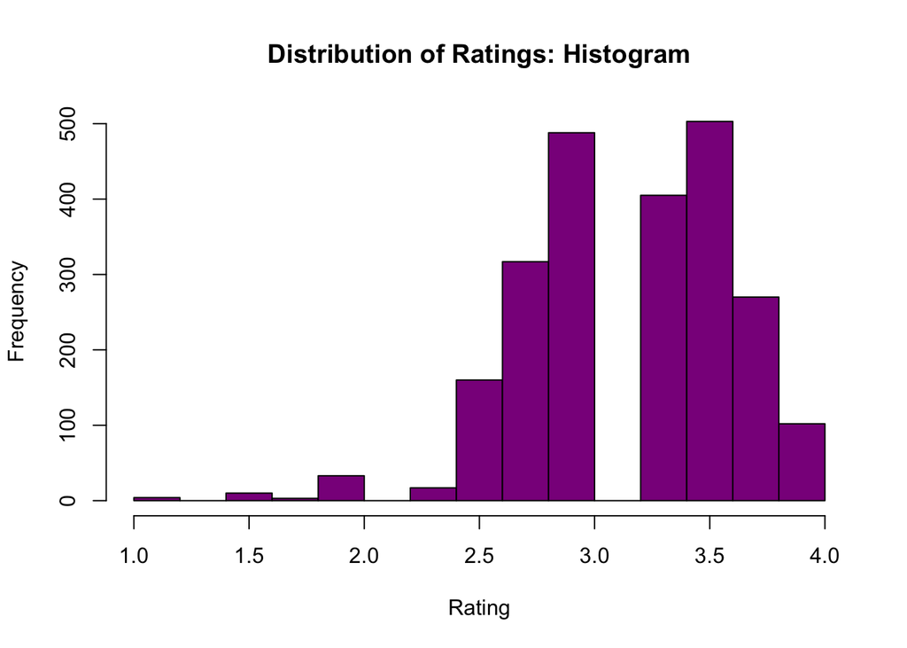

```r
hist(choco$Rating, main='Distribution of Ratings: Histogram', xlab='Rating', col='darkmagenta')
```

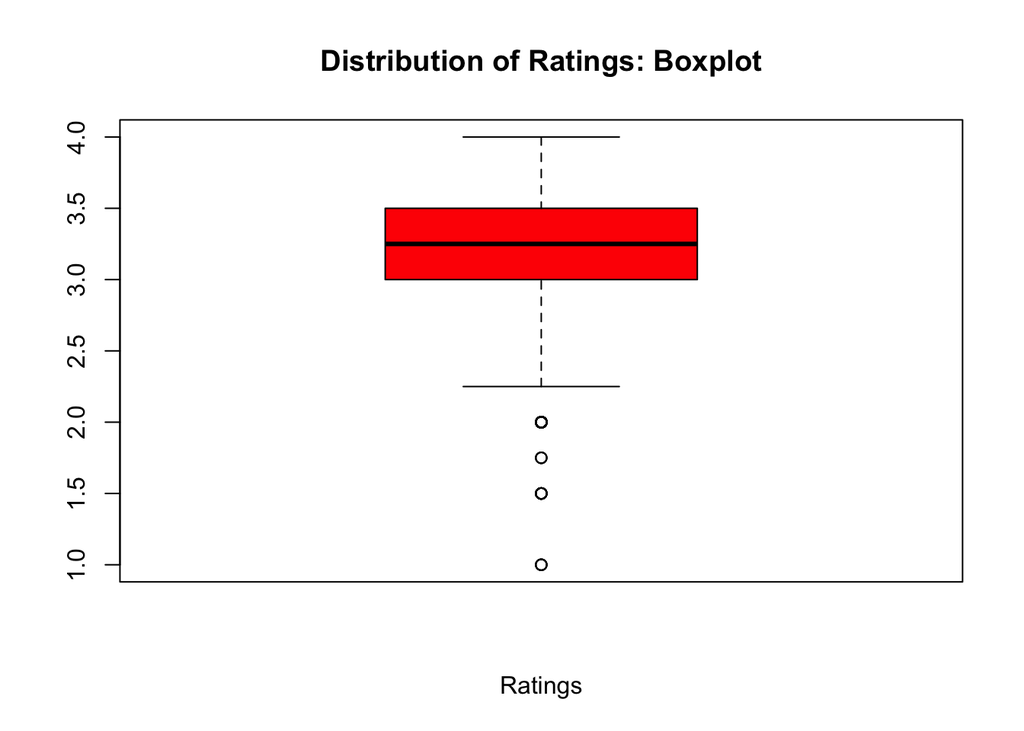

```r
boxplot(choco$Rating, main='Distribution of Ratings: Boxplot', xlab='Ratings', col='red')
```

The histogram is left skewed and bimodal, with potentially some outliers closer to the lower rating side.

The boxplot is also left skewed and has 4 outliers on the lower end of the ratings (below 2.25 rating).

**2.**

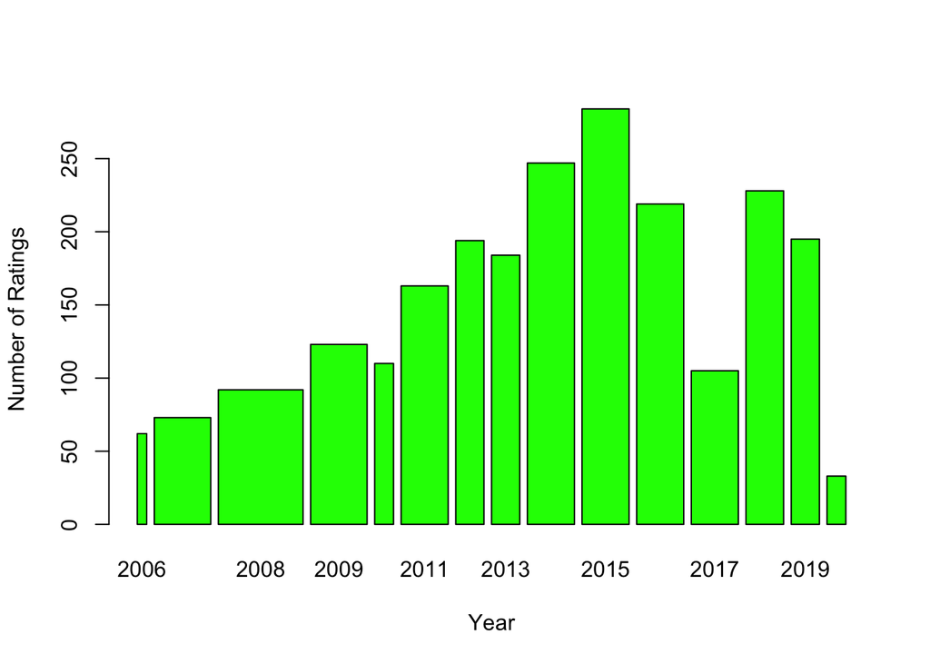

```r
date <- table(choco$Date)
REF <- table(choco$REF)
barplot(date, REF, xlab='Year', ylab='Number of Ratings', col='green')
```

**3.**

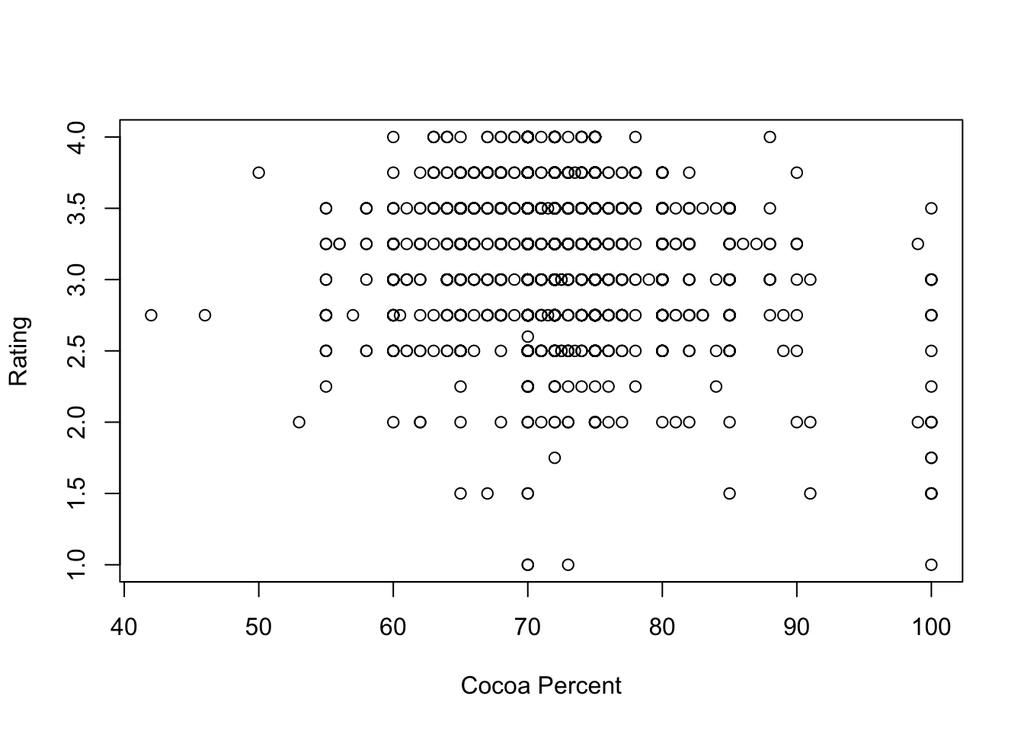

```r
c_percent <- table(choco$Cocoa_Percent)
rate <- table(choco$Rating)
plot(choco$Cocoa_Percent, choco$Rating, xlab='Cocoa Percent', ylab='Rating')
```

```r
cor(choco$Cocoa_Percent, choco$Rating)
```

```
## [1] -0.1510178
```

Based on the scatterplot and correlation coefficient of cocoa percentage and rating, rating does not depend on cocoa percentage. The correlation between the two is -.15 which is a weak negative relationship, and one can see the weak relationship in the scatterplot.

**4.**

```r
table(choco$Characteristics1, choco$Rating >= 3)
```

```
##
##                                  FALSE TRUE
##   accesible                          0    1
##   accessible                         0    1
##   acidic                             4    5
##   alluring aroma                     0    1
##   aluminum                           0    1
##   anise                              0    1
##   appealing smoke                    0    1
##   apple                              0    1
##   ashey                              1    0
##   assertive                          0    1
##   astringent                         1    4
##   baked                              0    1
##   baked bread                        0    1
##   balanced                           0    7
##   banana                             1    9
##   banana nut                         1    0
##   base cocoa                         0    3
##   base cocoa w/ palm notes           0    1
##   basic                              1    1
##   basic chocolate                    0    1
##   basic cocoa                        0    7
##   berries                            1    1
##   berry                              0    3
##   berry notes with sweet edge        0    1
##   bitter                             8    4
##   bitter coffee flavor               1    0
##   bitter then nutty rustic           0    1
##   black current                      0    1
##   black pepper                       1    6
##   black tea                          0    1
##   blackberries                       0    1
##   blackberry                         0    3
##   blackpepper                        1    0
##   bland                              3    4
##   bold                               0    7
##   bold cherry                        0    1
##   bready                             1    2
##   brief fruit note                   1    0
```

[output cut: 397 more lines]

```
##   very sweet                         4    3
##   vinegar                            1    0
##   walnuts                            0    1
##   watered down coffee                0    1
##   waxy                               2    9
##   waxy mouthfeel                     1    0
##   well balanced                      0    1
##   well defined                       0    1
##   wine                               0    1
##   wood                               0    1
##   woodsy                             0    1
##   woody                              4   13
##   XL nibs                            1    0
##   yellow fruit                       0    1
##   yogurt                             0    1
```

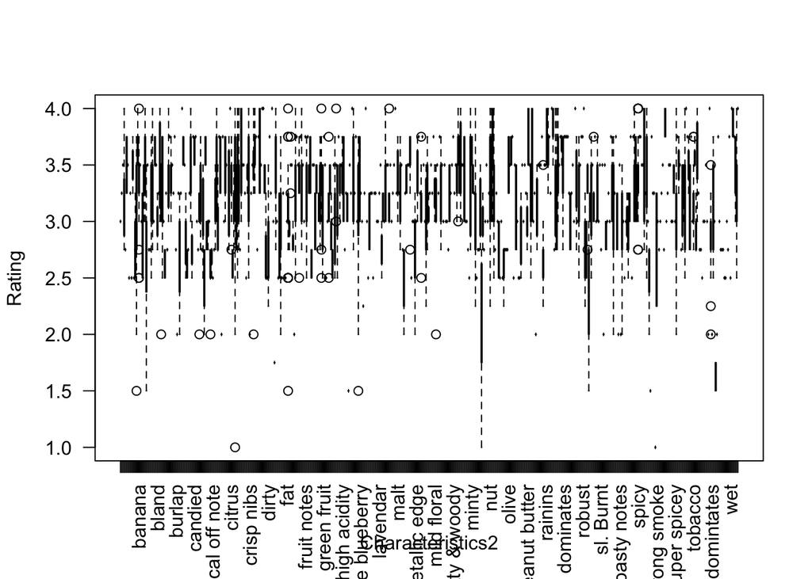

```r
boxplot(Rating~Characteristics2, data=choco, las=2)
```

According to the boxplot and rankings that are greater than 3, people tend to like fruity flavors such as banana and strawberry, but also enjoy other characteristics such as (but not limited to): coarse, cocoa, complex, creamy, dry, earthy, fatty, floral, grassy, gritty, intense, mild bitter, molasses, muted, nutty, oily, rich, roasty, rustic, sandy, smokey, smooth, spicy, sticky, sweet, tart, vanilla, and woody.

**5.**

1. One analysis I would like to perform is rating based on cocoa percentage. I will compare ratings with cocoa percentages to see if there is an ideal cocoa percentage in chocolate.

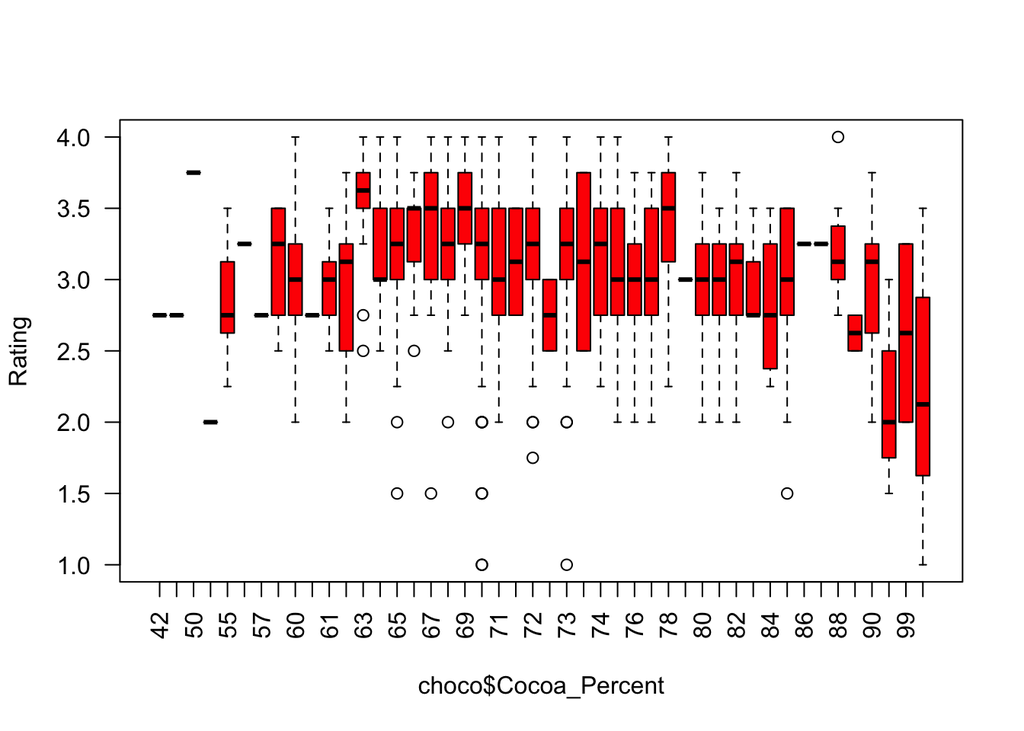

```r
boxplot(Rating~choco$Cocoa_Percent, data=choco, las=2, col='red')
```

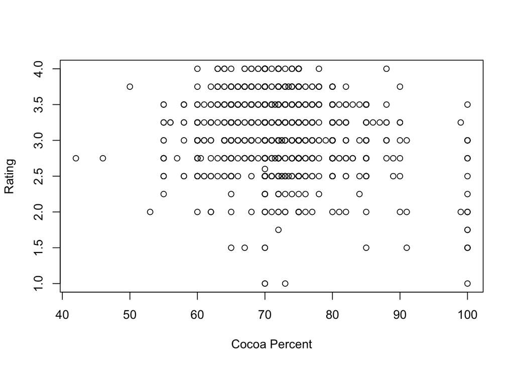

```r
plot(choco$Cocoa_Percent, choco$Rating, xlab='Cocoa Percent', ylab='Rating')
```

```r
cor(choco$Cocoa_Percent, choco$Rating)
```

```
## [1] -0.1510178
```

2. Another analysis I would like to perform is rating based on bean origin. I will be looking at ratings with the bean’s origin to see which countries produce the best beans.

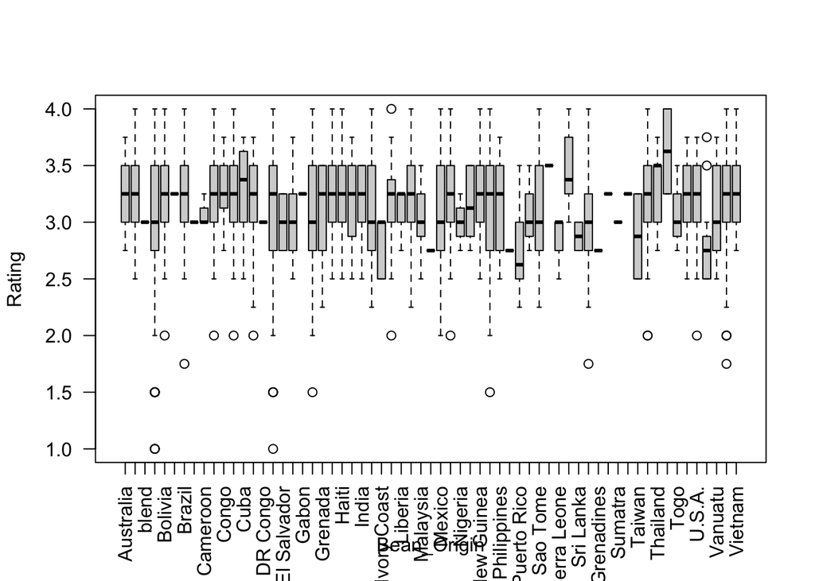

```r
rate_BO <- boxplot(Rating~Bean_Origin, data=choco, las=2)
```

```r
table(choco$Bean_Origin, choco$Rating >= 3, exclude=NULL)
```

```
##
##                         FALSE TRUE
##   Australia                 1    2
##   Belize                   10   57
##   blend                     0    1
##   Blend                    48  103
##   Bolivia                  17   55
##   Bolvia                    0    1
##   Brazil                   12   63
##   Burma                     0    1
##   Cameroon                  0    3
##   Colombia                 15   51
##   Congo                     1   10
##   Costa Rica                9   34
##   Cuba                      2   10
##   Dominican Republic       43  163
##   DR Congo                  0    1
##   Ecuador                  56  156
##   El Salvador               2    4
##   Fiji                      5   10
##   Gabon                     0    1
##   Ghana                    11   26
##   Grenada                   9   10
##   Guatemala                 9   44
##   Haiti                     5   19
##   Honduras                  6   17
##   India                     3   18
##   Indonesia                 7   11
##   Ivory Coast               2    3
##   Jamaica                   5   18
##   Liberia                   1    2
##   Madagascar               29  134
##   Malaysia                  2    5
##   Martinique                1    0
##   Mexico                   13   33
##   Nicaragua                18   74
##   Nigeria                   1    2
##   Panama                    2    6
##   Papua New Guinea          7   42
##   Peru                     64  156
```

[output cut: 10 more lines]

```
##   St.Vincent-Grenadines     1    0
##   Sulawesi                  0    1
##   Sumatra                   0    1
##   Suriname                  0    1
##   Taiwan                    1    1
##   Tanzania                 12   52
##   Thailand                  1    4
##   Tobago                    0    2
##   Togo                      1    2
##   Trinidad                  9   29
##   U.S.A.                    6   24
##   Uganda                    8    3
##   Vanuatu                   5    8
##   Venezuela                53  192
##   Vietnam                   8   56
```

My results are based on having a chocolate rating that is greater than or equal to 3. Additionally, I will only be mentioning bean origins that have 3 times as many, or more, TRUE values (rating of 3 or higher) than FALSE values (rating below 3). The best beans based on these are from: Belize, Bolivia, Brazil, Cameroon, Columbia, Congo, Costa Rica, Cuba, Dominican Republic, Guatemala, Haiti, India, Jamaica, Madagascar, Nicaragua, Panama, Papua New Guinea, Soloman Islands, Tanzania, Thailand, Trinidad, USA, Venezuela, and Vietnam.